# Acesso a dados com API e raspagem na web

Author

Daniel Capistrano

# 1 Acesso a dados estáticos

A maneira mais usual de acessar dados secundários para pesquisa social é baixar um arquivo de dados (*dataset*) da pagina oficial dessa fonte.

A vantagem dessa estratégia é a garantia de que os dados tem origem oficial e, uma vez baixados, pode-se trabalhar com o arquivo sem necessariamente ter acesso a internet. Ainda é bastante usual que pesquisadores utilizem esse procedimento para transmitir dados que não são públicos.

Esse processo, no entanto, tem algumas limitações. Primeiramente, esse processo é ineficiente se o usuário gostaria de acessar apenas parte do arquivo de dados. Além disso, existe uma maior dificuldade de atualizar ou corrigir os dados necessitando constante controle de versão.

**Exercício 1**

Acesse a [página oficial do WVS](https://www.worldvaluessurvey.org). Baixe os dados da onda 7 em formato do R (RDS) e SPSS (SAV). Abra os dois arquivos usando R. Existe alguma diferença entre os dois formatos?

# 2 API

APIs, da sigla em ingles para *application programming interface*, permitem acesso a dados de maneira mais dinamica e flexível. Trata-se basicamente de uma conexão entre dois computadores ou dois programas de computadores por meio de regras pré-definidas em relação a quais dados serão transmitidos.

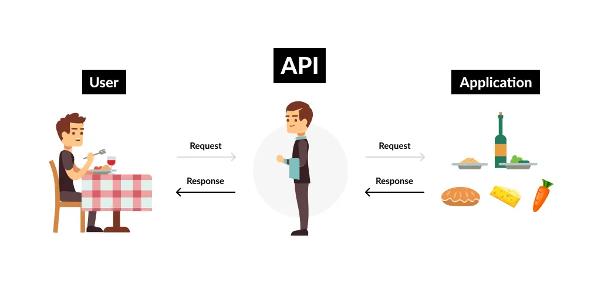

Image: Celeste Layne /A is for Application: API Basics

Em contraste com o acesso a dados estáticos, esses APIs permitem que os dados sejam atualizados/corrigidos regularmente e possam ser acessados de maneira mais eficiente.

## 2.1 API Wrappers

Antes de olhar como fazer requisições específicas usando API, é importante mencionar que diversos pacotes em R foram desenvolvidos para facilitar o acesso via API de maneira indireta, alguns exemplos:

- European Social Survey: [`essurvey`](https://docs.ropensci.org/essurvey/)
- World Bank: [`wbstats`](http://gshs-ornl.github.io/wbstats/)
- Eurostat: [`eurostat`](https://ropengov.github.io/eurostat/articles/eurostat_tutorial.html)

## 2.2 Instalação de pacotes

Vamos instalar o pacote [`httr2`](https://httr2.r-lib.org) que permite o acesso a APIs e tambem converter a resposta em dados estruturados para análise.

```r
install.packages("httr2")
```

## 2.3 Executar requisições

### 2.3.1 Camara dos Deputados

Vamos fazer uma requisição a base de dados da Camara dos Deputados: https://dadosabertos.camara.leg.br.

Primeiramente, vamos criar um objeto com o endereço da base de dados

```r
api <- "https://dadosabertos.camara.leg.br/api/v2"
```

Seguindo a [documentação do API](https://dadosabertos.camara.leg.br/swagger/api.html?tab=api), vamos fazer uma requisição específica:

```r
library(tidyverse)
library(httr2)

api_deputados  <- request(paste0(api, "/deputados"))

resposta  <-
    api_deputados |>
    req_url_query(nome="Benedita da Silva")|> # siglaPartido="PV"
    req_perform() |>
    resp_body_json(simplifyVector = TRUE)
```

Aqui vamos converter a resposta em um tabela:

```r
library(gt)
resposta |> pluck("dados") |> as_tibble() |> gt()
```

| id | uri | nome | siglaPartido | uriPartido | siglaUf | idLegislatura | urlFoto | email |
| --- | --- | --- | --- | --- | --- | --- | --- | --- |
| 73701 | https://dadosabertos.camara.leg.br/api/v2/deputados/73701 | Benedita da Silva | PT | https://dadosabertos.camara.leg.br/api/v2/partidos/36844 | RJ | 57 | https://www.camara.leg.br/internet/deputado/bandep/73701.jpg | dep.beneditadasilva@camara.leg.br |

## 2.4 Recursos adicionais

Repositório de APIs públicos: https://github.com/public-apis/public-apis

API Wrappers para dados abertos governamentais: https://ropengov.org/projects/.

Acessar OpenAI API: https://www.marlycormar.com/posts/2024-05-14-access-openAI-API/

**Exercício 2**

Despois de buscar na internet ou no repositório de APIs públicos, identifique um API que esteja relacionado com seu projeto de pesquisa.

# 3 Raspagem de dados

## 3.1 Robots.txt

Antes de realizar qualquer coleta automatizada de dados na internet, é importante verificar os direitos de acesso outorgados pelos criadores do conteúdo. Websites utilizam como padrão um arquivo chamado `robots.txt` que contém informações sobre quais dados podem ser coletaods e como eles podem ser utilizados.

Aqui está o conteúdo do [arquivo](https://www.camara.leg.br/robots.txt) localizado no site da camara dos deputados:

```r
camara_robots <- request("https://www.camara.leg.br/robots.txt") |> req_perform() |> resp_body_string()

cat(camara_robots)
```

```
User-Agent: *
Disallow: /sileg/prop_lista*
Disallow: /internet/sileg/prop_lista*
Disallow: /sileg/Prop_lista*
Disallow: /internet/sileg/Prop_lista*
Disallow: /*arvore-de-apensados
Disallow: /proposicoesWeb/prop_arvore_tramitacoes
Disallow: /sileg/prop_arvore_tramitacoes
Disallow: /internet/deputado/Dep_Lista*
Disallow: /transparencia/recursos-humanos/remuneracao/*
Disallow: /transparencia/recursos-humanos/contratos-terceirizacao*
Disallow: /transparencia/recursos-humanos/funcionarios*
Disallow: /*.tiff
Disallow: /*.bmp
Disallow: /*.gif
Disallow: /.lixeira*
Disallow: /*crawl=no
```

## 3.2 Instalação de pacotes

Além do pacote `httr2`, que pode ser utilizado para raspagem de dados, nós vamos utilizar o pacote [`rvest`](https://rvest.tidyverse.org) que foi desenvolvido especificamente para essa tarefa e possui algumas funcinalidades adicionais

```r
install.packages("rvest")
```

## 3.3 Coletando dados

Aqui vamos indicar o endereço da página que deve ser utilizada como referencia e baixar o conteúdo dessa pagina

```r
library(rvest)
pagina <- read_html("https://www.camara.leg.br/noticias")
```

[figure not shown]

Shamli Desai / Basic HTML Tags

Gerando uma tabela com todos os titulos marcados como ‘h3’ e seus respectivos links.

```r
resultado <-
    pagina |>
        html_elements("h3") |>
        map_df(~{
        link_node <- html_element(.x, "a")
        tibble(
            texto = html_text2(.x),
            link = link_node |> html_attr("href") |> replace_na("")
        )
    })

resultado |> gt()
```

| texto | link |
| --- | --- |
| Deputados retomam votações nesta terça no Plenário e nas comissões | https://www.camara.leg.br/noticias/1184334-deputados-retomam-votacoes-nesta-semana-no-plenario-e-nas-comissoes/ |
| Câmara declara a perda de mandato de sete deputados federais e convoca novos eleitos | https://www.camara.leg.br/noticias/1184072-camara-declara-a-perda-de-mandato-de-sete-deputados-federais-e-convoca-novos-eleitos/ |
| Hugo Motta: não podemos apoiar sanção de nações estrangeiras a membros de qualquer Poder da República | https://www.camara.leg.br/noticias/1184045-hugo-motta-nao-podemos-apoiar-sancao-de-nacoes-estrangeiras-a-membros-de-qualquer-poder-da-republica/ |
| A Voz do Brasil completa 90 anos marcando a comunicação pública brasileira | https://www.camara.leg.br/noticias/1182848-a-voz-do-brasil-completa-90-anos-marcando-a-comunicacao-publica-brasileira/ |
| Câmara finaliza modernização de alguns espaços e retoma atividades | https://www.camara.leg.br/noticias/1184595-camara-finaliza-modernizacao-de-alguns-espacos-e-retoma-atividades/ |
| Transtorno do espectro autista e doenças raras ganham destaque na Comissão de Saúde | https://www.camara.leg.br/noticias/1184637-transtorno-do-espectro-autista-e-doencas-raras-ganham-destaque-na-comissao-de-saude/ |
| Sancionada lei que aumenta pena para roubo e furto de cabos elétricos e de telefonia | https://www.camara.leg.br/noticias/1184174-sancionada-lei-que-aumenta-pena-para-roubo-e-furto-de-cabos-eletricos-e-de-telefonia/ |
| Lei que proíbe testes de cosméticos em animais já está em vigor | https://www.camara.leg.br/noticias/1184146-lei-que-proibe-testes-de-cosmeticos-em-animais-ja-esta-em-vigor/ |
| Nova lei libera recursos para investimentos de fundo científico e tecnológico | https://www.camara.leg.br/noticias/1184845-nova-lei-libera-recursos-para-investimentos-de-fundo-cientifico-e-tecnologico/ |
| Confira as principais matérias aprovadas no primeiro semestre | https://infograficos.camara.leg.br/retrospectiva-2025/ |
| PNE 2024-2034: Conheça as principais mudanças | https://infograficos.camara.leg.br/pne-2024-2034/ |

- Titulo
- Data
- Texto

```r
links <- resultado$link


map_dfr(links[1:5],~{
    pagina <- read_html(.x)
    tibble(
        titulo = pagina |> html_element("h1") |> html_text2(),
        data = pagina |> html_node(".g-artigo__data-hora") |> html_text2(),
        texto = pagina  |> html_node("#content-noticia")|> html_text2()
    ) |>
    mutate(texto = substr(texto, 1, 600))
}) |> gt()
```

| titulo | data | texto |
| --- | --- | --- |
| Deputados retomam votações nesta semana no Plenário e nas comissões | 04/08/2025 - 07:40 | Política e Administração Pública Deputados retomam votações nesta semana no Plenário e nas comissões Sessão do Plenário está marcada para a tarde de terça-feira (5) Compartilhe Versão para impressão v… |
| Câmara declara a perda de mandato de sete deputados federais e convoca novos eleitos | 31/07/2025 - 10:03 | Política e Administração Pública Câmara declara a perda de mandato de sete deputados federais e convoca novos eleitos A mudança está relacionada ao novo entendimento de como devem ser distribuídas as … |
| Hugo Motta: não podemos apoiar sanção de nações estrangeiras a membros de qualquer Poder da República | 30/07/2025 - 19:26 | Política e Administração Pública Hugo Motta: não podemos apoiar sanção de nações estrangeiras a membros de qualquer Poder da República O presidente da Câmara comentou em redes sociais as sanções finan… |
| A Voz do Brasil completa 90 anos marcando a comunicação pública brasileira | 23/07/2025 - 11:47 • Atualizado em 05/08/2025 - 09:01 | Ciência, tecnologia e Comunicações A Voz do Brasil completa 90 anos marcando a comunicação pública brasileira No dia 5 de agosto, o Congresso Nacional realiza sessão solene em comemoração aos 90 anos … |
| Câmara finaliza modernização de alguns espaços e retoma atividades | 04/08/2025 - 15:57 | Política e Administração Pública Câmara finaliza modernização de alguns espaços e retoma atividades Foram concluídas intervenções no corredor das comissões, no túnel que liga os anexos 4 e 2 e no 10º … |

**Exercício 3**

- Aumentar o número de caracteres do texto da noticia de 600 para 1000.
- Adicionar uma coluna contendo o número de comentários de cada notícia
- Identificar uma página que seja relevante para o grupo e pensar em formas de automatizar a coleta de dados.